# Exam 2 Answer Booklet

Dr Wayne Stewart

11/8/2019

# Introduction

Name: Collin Dabbieri

Grade 2,3,4 please

Please place answers to question 2-4 here:

# Question 2

```r
library(readxl)
prodqual=read_excel("./PRODQUAL.XLS")
head(prodqual)
```

```
## # A tibble: 6 x 3
##    TEMP PRESSURE QUALITY
##   <dbl>    <dbl>   <dbl>
## 1    80       50    50.8
## 2    80       50    50.7
## 3    80       50    49.4
## 4    80       55    93.7
## 5    80       55    90.9
## 6    80       55    90.9
```

## a)

$$E(y)=\beta_0+\beta_1x_1+\beta_2x_2+\beta_3x_1x_2+\beta_4x_1^2+\beta_5x_2^2$$

## b)

```r
qual=prodqual$QUALITY
temp=prodqual$TEMP
pressure=prodqual$PRESSURE
temp2=temp^2
press2=pressure^2
model=lm(qual~temp+pressure+temp:pressure+temp2+press2)
summary(model)
```

```
##
## Call:
## lm(formula = qual ~ temp + pressure + temp:pressure + temp2 +
##     press2)
##
## Residuals:
##      Min       1Q   Median       3Q      Max
## -2.82593 -0.95370  0.07407  1.01852  2.95185
##
## Coefficients:
##                 Estimate Std. Error t value Pr(>|t|)
## (Intercept)   -5.128e+03  1.103e+02  -46.49  < 2e-16 ***
## temp           3.110e+01  1.344e+00   23.13  < 2e-16 ***
## pressure       1.397e+02  3.140e+00   44.51  < 2e-16 ***
## temp2         -1.334e-01  6.853e-03  -19.46 6.46e-15 ***
## press2        -1.144e+00  2.741e-02  -41.74  < 2e-16 ***
## temp:pressure -1.455e-01  9.692e-03  -15.01 1.06e-12 ***
## ---
## Signif. codes:  0 '***' 0.001 '**' 0.01 '*' 0.05 '.' 0.1 ' ' 1
##
## Residual standard error: 1.679 on 21 degrees of freedom
## Multiple R-squared:  0.993,  Adjusted R-squared:  0.9913
## F-statistic: 596.3 on 5 and 21 DF,  p-value: < 2.2e-16
```

## c)

The p-value from the F-test (2.2e-16) tells us that the model is adequate at the 95% confidence level.

## d)

99.3% of the variability in the response is explained by the model. This comes from the $R^2$ value

$$R^2=1-\frac{SSE}{TSS}$$

## e)

$$y=-5.128e3+3.11e1x_1+1.397e2x_2-1.334e-1x_3-1.144e0x_4-1.455e-1x_5$$

Maximum point has a slope of 0

```r
A=matrix(c(-5.128e3,3.11e1,1.397e2,-1.334e-1,-1.144e0,-1.455e-1))
```

# Question 3

```r
library(s20x)
```

## a)

```r
data(seeds.df)
head(seeds.df)
```

```
##   Light Water Count
## 1     N     1    22
## 2     N     1    25
## 3     N     1    27
## 4     N     1    23
## 5     N     2    41
## 6     N     2    46
```

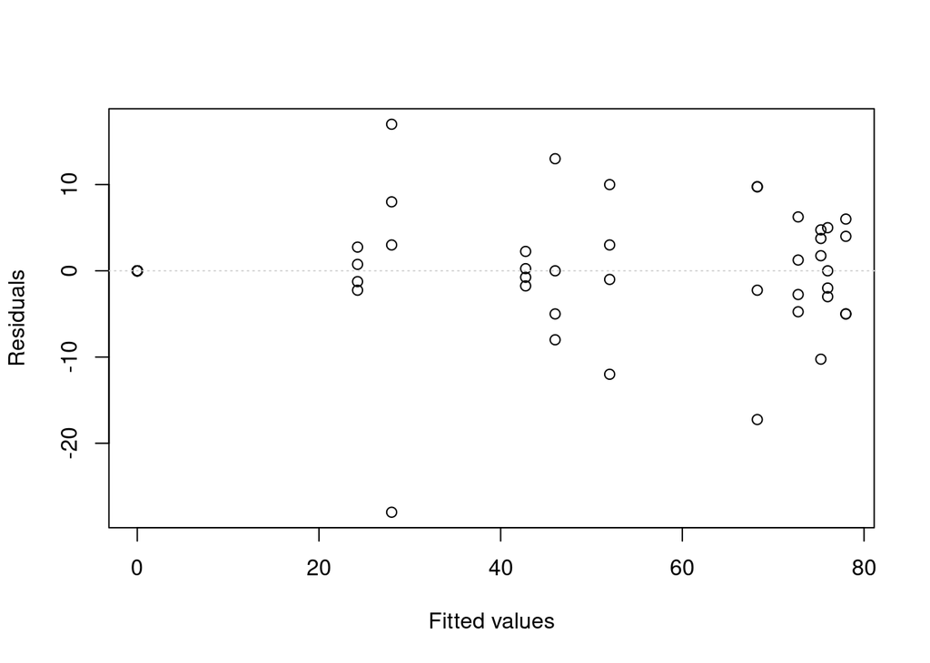

```r
seeds.df=within(seeds.df,{Water.F=factor(Water)})
model1=lm(Count~Light+Water.F+Light:Water.F,data=seeds.df)
eovcheck(model1)
```

There does not appear to be fanning, I believe we can say that it is plausible that the variance is constant.

## b)

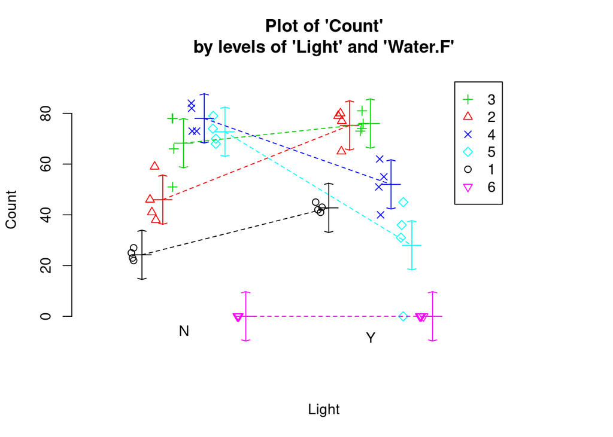

```r
interactionPlots(Count~Light+Water.F,data=seeds.df)
```

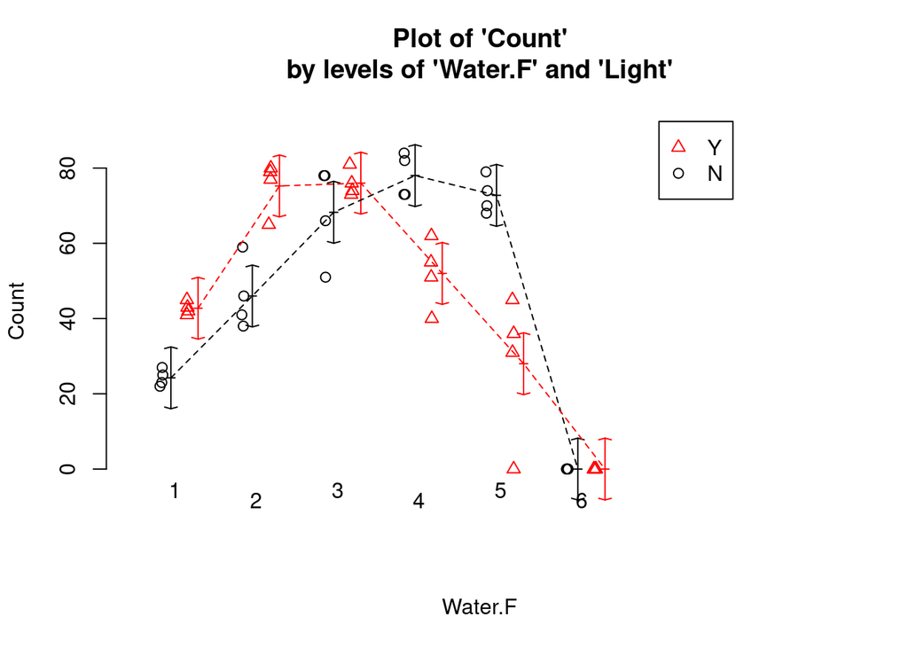

```r
interactionPlots(Count~Water.F+Light,data=seeds.df)
```

There is some pretty strong evidence for interaction here. The lines are certainly not parallel.

## c)

```r
summary2way(model1)
```

```
## ANOVA Table:
##               Df Sum Squares Mean Square F-statistic p-value
## Light          1        77.5        77.5       1.103 0.30057
## Water.F        5     28348.2      5669.6      80.683 0.00000
## Light:Water.F  5      7795.4      1559.1      22.187 0.00000
## Residuals     36      2529.8        70.3
```

the p-value for the interaction term is ~0. We have strong evidence for interaction.

## d)

The main effects appear to be water and the interaction term. The light term is not significant at the 95% confidence level.

## e)

The most parsiminous model possible will only use either Water or Light

```r
model2=lm(Count~Water.F+Light:Water.F,data=seeds.df)
anova(model2)
```

```
## Analysis of Variance Table
##
## Response: Count
##               Df  Sum Sq Mean Sq F value    Pr(>F)
## Water.F        5 28348.2  5669.6  80.683 < 2.2e-16 ***
## Water.F:Light  6  7872.9  1312.1  18.673 9.959e-10 ***
## Residuals     36  2529.7    70.3
## ---
## Signif. codes:  0 '***' 0.001 '**' 0.01 '*' 0.05 '.' 0.1 ' ' 1
```

```r
model3=lm(Count~Water.F,data=seeds.df)
summary(model3)
```

```
##
## Call:
## lm(formula = Count ~ Water.F, data = seeds.df)
##
## Residuals:
##     Min      1Q  Median      3Q     Max
## -50.375  -8.875   0.000   8.594  28.625
##
## Coefficients:
##             Estimate Std. Error t value Pr(>|t|)
## (Intercept)   33.500      5.564   6.021 3.71e-07 ***
## Water.F2      27.125      7.869   3.447 0.001300 **
## Water.F3      38.625      7.869   4.909 1.43e-05 ***
## Water.F4      31.500      7.869   4.003 0.000249 ***
## Water.F5      16.875      7.869   2.145 0.037824 *
## Water.F6     -33.500      7.869  -4.257 0.000114 ***
## ---
## Signif. codes:  0 '***' 0.001 '**' 0.01 '*' 0.05 '.' 0.1 ' ' 1
##
## Residual standard error: 15.74 on 42 degrees of freedom
## Multiple R-squared:  0.7316, Adjusted R-squared:  0.6996
## F-statistic: 22.89 on 5 and 42 DF,  p-value: 5.135e-11
```

So we’re left with only Water.

Water has 6 levels, 5 dummy variables

$$E(y)=\beta_0+\beta_1x_1+\beta_2x_2+\beta_3x_3+\beta_4x_4+\beta_5x_5$$

# Question 4

## a)

$$E(y)=\beta_0+\beta_1x_1+\beta_2x_2+\beta_3x_3+\beta_4x_4$$

the $x_1$ term is the dummy variable for treatments. Terms $x_2,x_3,x_4$ are dummy variables for blocks

## b)

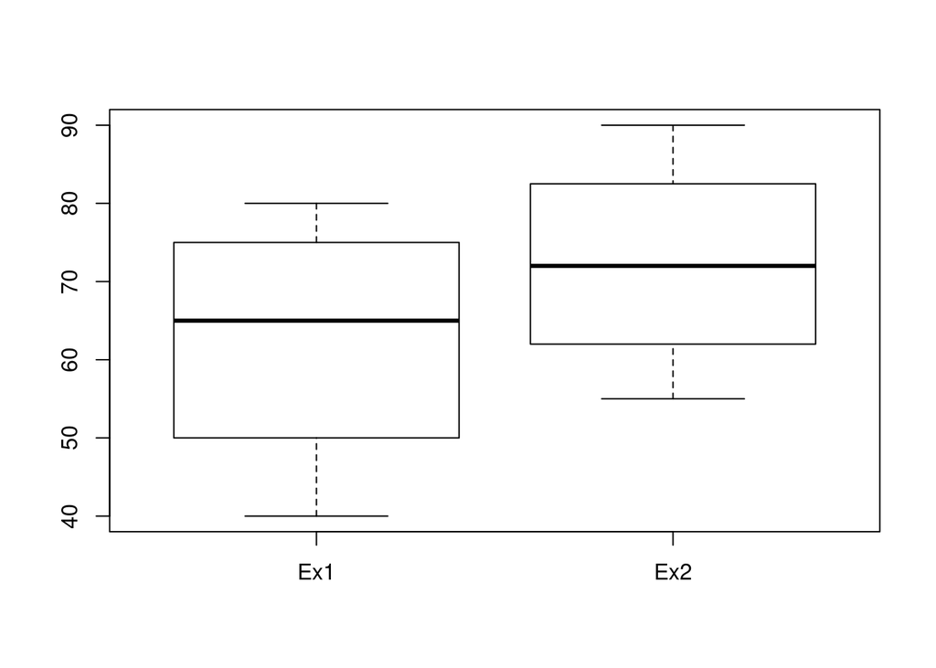

```r
Ex1=c(40,60,70,80)
Ex2=c(55,69,75,90)

boxplot(cbind(Ex1,Ex2))
```

```r
t.test(Ex1,Ex2,paired=T)
```

```
##
##  Paired t-test
##
## data:  Ex1 and Ex2
## t = -4.7411, df = 3, p-value = 0.0178
## alternative hypothesis: true difference in means is not equal to 0
## 95 percent confidence interval:
##  -16.294681  -3.205319
## sample estimates:
## mean of the differences
##                   -9.75
```

```r
Exams=c(Ex1,Ex2)
Treatments=rep(c("T1","T2"),c(4,4))
Blocks=rep(c("1","2","3","4"),2)
Exams
```

```
## [1] 40 60 70 80 55 69 75 90
```

```r
Treatments
```

```
## [1] "T1" "T1" "T1" "T1" "T2" "T2" "T2" "T2"
```

```r
Blocks
```

```
## [1] "1" "2" "3" "4" "1" "2" "3" "4"
```

```r
#we want to test if treatment means are equal

model_c=lm(Exams~Treatments+Blocks)
model_r=lm(Exams~Blocks)
```

## d)

```r
anova(model_r,model_c)
```

```
## Analysis of Variance Table
##
## Model 1: Exams ~ Blocks
## Model 2: Exams ~ Treatments + Blocks
##   Res.Df     RSS Df Sum of Sq      F Pr(>F)
## 1      4 215.500
## 2      3  25.375  1    190.12 22.478 0.0178 *
## ---
## Signif. codes:  0 '***' 0.001 '**' 0.01 '*' 0.05 '.' 0.1 ' ' 1
```

The p-value from the partial F statistic tells us that we can say with 95% confidence that the treatment means are different. Meaning we can say with confidence that the mean for exam1 is different than the mean for exam2

## e)

$T_{calc}=-4.7411$

$F_{calc}=22.478$

show numerically

```r
-4.7411/22.478
```

```
## [1] -0.2109218
```

$$T_{calc}=-0.21F_{calc}$$

IGNORE BELOW

$$F_{calc}=\frac{\frac{SST}{k}}{\frac{SSE}{n-(k+1)}}$$

$$SSE=\sum (Y_i-\hat{Y_i})^2$$

$$SST=\sum n_i (\bar{y_i}-\bar{y})^2$$

$$F=\frac{\frac{\chi^2}{\nu}}{\frac{\chi^2}{\nu}}$$

$$T=\frac{Z}{\sqrt{\frac{\chi^2}{\nu}}}$$